# QMEE 2021

Ali

14/01/2021

## Calss 1

- R basics

```r
x <- 1
## vector
words <- c("hello", "a")
v <- 1:5
xx <- c(1,"hello") ## ? coercion
str(xx)
```

```
##  chr [1:2] "1" "hello"
```

```r
## turned 1 to a char to make them the same type

## lists
L <- list(1,"hello")
L[[1]]
```

```
## [1] 1
```

## Calss 2

- we are going to continue intro to R
- then github with JD

```r
x <- c(2,3,1)
y <- c(2,2,6)
t.test(x,y,var.equal=T)
```

```
##
##  Two Sample t-test
##
## data:  x and y
## t = -0.91766, df = 4, p-value = 0.4107
## alternative hypothesis: true difference in means is not equal to 0
## 95 percent confidence interval:
##  -5.367415  2.700748
## sample estimates:
## mean of x mean of y
##  2.000000  3.333333
```

```r
# R is case sensative m and M are diff
# tab is your friend, type v and tab and R shows you everything starts with v
# no space in var name, what is the best var name? not long, long enough
# Read the style points in the course page

# we talked about vector and lists, more complicated objects

# dataframe, list of columns, each col is a vector, rows are observations
dd <- data.frame(a=1:3,b=c("hello", "good", "bad"))

factor(c("sparrow","robin","bat"))## is different from c()
```

```
## [1] sparrow robin   bat
## Levels: bat robin sparrow
```

```r
species <- c("sparrow","robin","bat")
# Note: most of variables are numerics or factors
# another kind of dataframe called tibble

## Loops
 v<- 1:5
for(x in v){
  if(x>=4)
    print(x^2)
}
```

```
## [1] 16
## [1] 25
```

```r
 ## Logical
 x=1
  x!=2 ## bang
```

```
## [1] TRUE
```

```r
  x==1 & 3==5
```

```
## [1] FALSE
```

```r
 x==1 | 3==5
```

```
## [1] TRUE
```

```r
 species == "robin" ## is applied to the whole vector
```

```
## [1] FALSE  TRUE FALSE
```

```r
 # we want to refer to a specific element
 species[2]
```

```
## [1] "robin"
```

```r
 # a row from a df, several ways:
 dd[["a"]]
```

```
## [1] 1 2 3
```

```r
 dd$a ## shortcut
```

```
## [1] 1 2 3
```

```r
 dd[[1]] ## refering to element by position
```

```
## [1] 1 2 3
```

```r
# ########################################
## The tidyverse (by Hadly Wicom)
# ########################################
 library(tidyverse)
 # a set of packages, can be easier to do complicated things, speed
 # disadvantages: instability with base R
 # where are you putting your stuff, data
 getwd()
```

```
## [1] "/home/ag/classes/QMEE_ali/scripts"
```

```r
 dir.create("data") ## make sure you are in the dir of your course where you want to creat a data dir
```

```r
 download.file(url="https://ndownloader.figshare.com/files/2292169",
               destfile = "data/newdata.csv")

 surveys <- read_csv("data/newdata.csv")
## it is a tibble
 head(surveys)
```

```
## # A tibble: 6 x 13
##   record_id month   day  year plot_id species_id sex   hindfoot_length weight
##       <dbl> <dbl> <dbl> <dbl>   <dbl> <chr>      <chr>           <dbl>  <dbl>
## 1         1     7    16  1977       2 NL         M                  32     NA
## 2        72     8    19  1977       2 NL         M                  31     NA
## 3       224     9    13  1977       2 NL         <NA>               NA     NA
## 4       266    10    16  1977       2 NL         <NA>               NA     NA
## 5       349    11    12  1977       2 NL         <NA>               NA     NA
## 6       363    11    12  1977       2 NL         <NA>               NA     NA
## # … with 4 more variables: genus <chr>, species <chr>, taxa <chr>,
## #   plot_type <chr>
```

```r
## manipulating data verbs: select (taking col), filter (taking rows), ..
 select(surveys, month, day)
```

```
## # A tibble: 34,786 x 2
##    month   day
##    <dbl> <dbl>
##  1     7    16
##  2     8    19
##  3     9    13
##  4    10    16
##  5    11    12
##  6    11    12
##  7    12    10
##  8     1     8
##  9     2    18
## 10     3    11
## # … with 34,776 more rows
```

```r
 select(surveys,-genus)
```

```
## # A tibble: 34,786 x 12
##    record_id month   day  year plot_id species_id sex   hindfoot_length weight
##        <dbl> <dbl> <dbl> <dbl>   <dbl> <chr>      <chr>           <dbl>  <dbl>
##  1         1     7    16  1977       2 NL         M                  32     NA
##  2        72     8    19  1977       2 NL         M                  31     NA
##  3       224     9    13  1977       2 NL         <NA>               NA     NA
##  4       266    10    16  1977       2 NL         <NA>               NA     NA
##  5       349    11    12  1977       2 NL         <NA>               NA     NA
##  6       363    11    12  1977       2 NL         <NA>               NA     NA
##  7       435    12    10  1977       2 NL         <NA>               NA     NA
##  8       506     1     8  1978       2 NL         <NA>               NA     NA
##  9       588     2    18  1978       2 NL         M                  NA    218
## 10       661     3    11  1978       2 NL         <NA>               NA     NA
## # … with 34,776 more rows, and 3 more variables: species <chr>, taxa <chr>,
## #   plot_type <chr>
```

```r
 filter(surveys, (month >11|month<3) & species== "albigula")  ## if you put , in filter it means & &
```

```
## # A tibble: 202 x 13
##    record_id month   day  year plot_id species_id sex   hindfoot_length weight
##        <dbl> <dbl> <dbl> <dbl>   <dbl> <chr>      <chr>           <dbl>  <dbl>
##  1       435    12    10  1977       2 NL         <NA>               NA     NA
##  2       506     1     8  1978       2 NL         <NA>               NA     NA
##  3       588     2    18  1978       2 NL         M                  NA    218
##  4      2406     1    16  1980       2 NL         F                  33    184
##  5      5180     1     1  1982       2 NL         M                  NA    206
##  6      5299     1    25  1982       2 NL         F                  32    165
##  7      5485     2    24  1982       2 NL         M                  34    202
##  8      8755    12     9  1983       2 NL         F                  32    150
##  9     11215    12     8  1985       2 NL         F                  32    160
## 10     12299     2     1  1987       2 NL         M                  32    253
## # … with 192 more rows, and 4 more variables: genus <chr>, species <chr>,
## #   taxa <chr>, plot_type <chr>
```

```r
 ## PIPE

 survey2 <- (surveys
   %>% filter(month >11)
   %>% select(-day)
   %>% mutate(LW=weight/100) ## to change the name of var or creat a new var
 )

 # keyboard shortcut, go to helpyboard shortcut keys
 # %>% ctrl + shift +m

# other verbs; group_by(), summerise()
```

## Calss 3

Date: Jan 21, 2021 see chap 9 and 10 of https://happygitwithr.com/

```r
## villageTable <- read_csv("/data/villageTable.csv")
## where is this data?
```

## Calss 4

Date: Jan 26, 2021

- different functions and diff forms that you want to put your data in
- talking about malaria data set
- Data maintenance; tidy data the core of it, into database form that is relational (tibble, dataframe, they know how to connect to each others through ids), long format
- long format; tidy data, make data as clean as possible, break the dataset into different related tables so I can put the data into level I want (individual table, household table, village table, etc), we use keys
- choose your work flow
  - example; tibble (time, S,I,R) from wide format to long format using pivot_longer pivot_longer(data, cols=!time , names_to=“class”, values_to=“people”)
    - cols=!time; don’t treat time as value variable (! is called Bang)
    - we are treat S I R as same kind and time different
    - result -> columns would be “time,class,people”
  - Importing data;
  - summarize; check the numbers are nums, dates are dates, categorical vars are factors
- How to make relational tables?
  - a table at level of people
  - a table at the level of sampling events,
  - a table

```r
library(tidyverse)

QMEEpath <- "~/classes/QMEE/docs/data/"
list.files(path=QMEEpath, pattern="*.csv") # create list of all .csv files in folder
```

```
##  [1] "ants.csv"               "CA_homicide.csv"        "CA_popdat.csv"
##  [4] "dll.csv"                "lizards.csv"            "parademo.csv"
##  [7] "portal_data_joined.csv" "religion_basic.ccsv"    "skewdat.csv"
## [10] "village.csv"
```

```r
file_name <- "village.csv"
villageTable <- read_csv(file = paste(QMEEpath,file_name, sep=''))
print(villageTable
      %>% group_by(vname) ## village name
      %>% summarize(count= n())
      %>% filter(count>1)
      )
```

```
## # A tibble: 2 x 2
##   vname      count
##   <chr>      <int>
## 1 Daurawa        2
## 2 Sabon Gari     2
```

```r
file_name2 <- "parademo.csv"
parasiteTable <- read_csv(file = paste(QMEEpath,file_name2, sep=''))
print(parasiteTable
      %>%  group_by(id, village, compound)
      %>% summarize(count=n())
      %>% group_by(id)
      %>% summarize(count=n())
      %>% filter(count>1)
      %>% arrange(desc(count))

)
```

```
## # A tibble: 756 x 2
##       id count
##    <dbl> <int>
##  1  6571     4
##  2  6572     4
##  3  6573     4
##  4  6574     4
##  5  6575     4
##  6  6576     4
##  7  6577     4
##  8  6578     4
##  9    41     3
## 10  1081     3
## # … with 746 more rows
```

- correction tables
  - make a table
  - make a dictionary

```r
download.file(url="https://github.com/mac-theobio/QMEE/blob/master/docs/data/parademo.csv",
               destfile = "data/parademo.csv")
```

## Calss 5

Date: Thursday Jan 28, 2021

```r
QMEEpath <- "~/classes/QMEE/docs/data/"
list.files(path=QMEEpath, pattern="*.csv") # create list of all .csv files in folder
```

```
##  [1] "ants.csv"               "CA_homicide.csv"        "CA_popdat.csv"
##  [4] "dll.csv"                "lizards.csv"            "parademo.csv"
##  [7] "portal_data_joined.csv" "religion_basic.ccsv"    "skewdat.csv"
## [10] "village.csv"
```

```r
file_name <- "village.csv"

village <- read.csv(file = paste(QMEEpath,file_name, sep=''))


apropos("plot") ## find any appropriate plot
```

```
##  [1] "assocplot"           "autoplot"            "barplot"
##  [4] "barplot.default"     "benchplot"           "biplot"
##  [7] "boxplot"             "boxplot.default"     "boxplot.matrix"
## [10] "boxplot.stats"       "cdplot"              "coplot"
## [13] "draw_key_boxplot"    "draw_key_dotplot"    "fourfoldplot"
## [16] "geom_boxplot"        "geom_dotplot"        "GeomBoxplot"
## [19] "GeomDotplot"         "ggplot"              "ggplot_add"
## [22] "ggplot_build"        "ggplot_gtable"       "ggplotGrob"
## [25] "interaction.plot"    "is.ggplot"           "lag.plot"
## [28] "last_plot"           "matplot"             "monthplot"
## [31] "mosaicplot"          "plot"                "plot"
## [34] "plot.default"        "plot.design"         "plot.ecdf"
## [37] "plot.function"       "plot.new"            "plot.spec.coherency"
## [40] "plot.spec.phase"     "plot.stepfun"        "plot.ts"
## [43] "plot.window"         "plot.xy"             "preplot"
## [46] "qplot"               "qqplot"              "quickplot"
## [49] "recordPlot"          "replayPlot"          "savePlot"
## [52] "screeplot"           "set_last_plot"       "spineplot"
## [55] "stat_boxplot"        "StatBoxplot"         "sunflowerplot"
## [58] "termplot"            "ts.plot"
```

```r
head(mtcars) ## this is a built in data set
```

```
##                    mpg cyl disp  hp drat    wt  qsec vs am gear carb
## Mazda RX4         21.0   6  160 110 3.90 2.620 16.46  0  1    4    4
## Mazda RX4 Wag     21.0   6  160 110 3.90 2.875 17.02  0  1    4    4
## Datsun 710        22.8   4  108  93 3.85 2.320 18.61  1  1    4    1
## Hornet 4 Drive    21.4   6  258 110 3.08 3.215 19.44  1  0    3    1
## Hornet Sportabout 18.7   8  360 175 3.15 3.440 17.02  0  0    3    2
## Valiant           18.1   6  225 105 2.76 3.460 20.22  1  0    3    1
```

```r
library(tidyverse)
find("filter") ## the order of packages that R is using function filter
```

```
## [1] "package:dplyr" "package:stats"
```

```r
m <- as_tibble(mtcars) ## tibble mostly behave like dataframe, the primary case that makes it different
print(m)
```

```
## # A tibble: 32 x 11
##      mpg   cyl  disp    hp  drat    wt  qsec    vs    am  gear  carb
##    <dbl> <dbl> <dbl> <dbl> <dbl> <dbl> <dbl> <dbl> <dbl> <dbl> <dbl>
##  1  21       6  160    110  3.9   2.62  16.5     0     1     4     4
##  2  21       6  160    110  3.9   2.88  17.0     0     1     4     4
##  3  22.8     4  108     93  3.85  2.32  18.6     1     1     4     1
##  4  21.4     6  258    110  3.08  3.22  19.4     1     0     3     1
##  5  18.7     8  360    175  3.15  3.44  17.0     0     0     3     2
##  6  18.1     6  225    105  2.76  3.46  20.2     1     0     3     1
##  7  14.3     8  360    245  3.21  3.57  15.8     0     0     3     4
##  8  24.4     4  147.    62  3.69  3.19  20       1     0     4     2
##  9  22.8     4  141.    95  3.92  3.15  22.9     1     0     4     2
## 10  19.2     6  168.   123  3.92  3.44  18.3     1     0     4     4
## # … with 22 more rows
```

```r
# difference between dataframe and tibble, see below
str(mtcars[,1])
```

```
##  num [1:32] 21 21 22.8 21.4 18.7 18.1 14.3 24.4 22.8 19.2 ...
```

```r
str(m[,1])
```

```
## tibble [32 × 1] (S3: tbl_df/tbl/data.frame)
##  $ mpg: num [1:32] 21 21 22.8 21.4 18.7 18.1 14.3 24.4 22.8 19.2 ...
```

```r
m %>% group_by(cyl) ## group it by single var, ie cylender
```

```
## # A tibble: 32 x 11
## # Groups:   cyl [3]
##      mpg   cyl  disp    hp  drat    wt  qsec    vs    am  gear  carb
##    <dbl> <dbl> <dbl> <dbl> <dbl> <dbl> <dbl> <dbl> <dbl> <dbl> <dbl>
##  1  21       6  160    110  3.9   2.62  16.5     0     1     4     4
##  2  21       6  160    110  3.9   2.88  17.0     0     1     4     4
##  3  22.8     4  108     93  3.85  2.32  18.6     1     1     4     1
##  4  21.4     6  258    110  3.08  3.22  19.4     1     0     3     1
##  5  18.7     8  360    175  3.15  3.44  17.0     0     0     3     2
##  6  18.1     6  225    105  2.76  3.46  20.2     1     0     3     1
##  7  14.3     8  360    245  3.21  3.57  15.8     0     0     3     4
##  8  24.4     4  147.    62  3.69  3.19  20       1     0     4     2
##  9  22.8     4  141.    95  3.92  3.15  22.9     1     0     4     2
## 10  19.2     6  168.   123  3.92  3.44  18.3     1     0     4     4
## # … with 22 more rows
```

```r
m %>% group_by(cyl) %>% ungroup() ## group it by cylender and ungroup it
```

```
## # A tibble: 32 x 11
##      mpg   cyl  disp    hp  drat    wt  qsec    vs    am  gear  carb
##    <dbl> <dbl> <dbl> <dbl> <dbl> <dbl> <dbl> <dbl> <dbl> <dbl> <dbl>
##  1  21       6  160    110  3.9   2.62  16.5     0     1     4     4
##  2  21       6  160    110  3.9   2.88  17.0     0     1     4     4
##  3  22.8     4  108     93  3.85  2.32  18.6     1     1     4     1
##  4  21.4     6  258    110  3.08  3.22  19.4     1     0     3     1
##  5  18.7     8  360    175  3.15  3.44  17.0     0     0     3     2
##  6  18.1     6  225    105  2.76  3.46  20.2     1     0     3     1
##  7  14.3     8  360    245  3.21  3.57  15.8     0     0     3     4
##  8  24.4     4  147.    62  3.69  3.19  20       1     0     4     2
##  9  22.8     4  141.    95  3.92  3.15  22.9     1     0     4     2
## 10  19.2     6  168.   123  3.92  3.44  18.3     1     0     4     4
## # … with 22 more rows
```

```r
m %>% group_by(cyl) %>% summarise(mpg=mean(mpg))
```

```
## # A tibble: 3 x 2
##     cyl   mpg
##   <dbl> <dbl>
## 1     4  26.7
## 2     6  19.7
## 3     8  15.1
```

```r
m %>% group_by(cyl,gear)
```

```
## # A tibble: 32 x 11
## # Groups:   cyl, gear [8]
##      mpg   cyl  disp    hp  drat    wt  qsec    vs    am  gear  carb
##    <dbl> <dbl> <dbl> <dbl> <dbl> <dbl> <dbl> <dbl> <dbl> <dbl> <dbl>
##  1  21       6  160    110  3.9   2.62  16.5     0     1     4     4
##  2  21       6  160    110  3.9   2.88  17.0     0     1     4     4
##  3  22.8     4  108     93  3.85  2.32  18.6     1     1     4     1
##  4  21.4     6  258    110  3.08  3.22  19.4     1     0     3     1
##  5  18.7     8  360    175  3.15  3.44  17.0     0     0     3     2
##  6  18.1     6  225    105  2.76  3.46  20.2     1     0     3     1
##  7  14.3     8  360    245  3.21  3.57  15.8     0     0     3     4
##  8  24.4     4  147.    62  3.69  3.19  20       1     0     4     2
##  9  22.8     4  141.    95  3.92  3.15  22.9     1     0     4     2
## 10  19.2     6  168.   123  3.92  3.44  18.3     1     0     4     4
## # … with 22 more rows
```

```r
m %>% group_by(cyl,gear) %>% summarise(mpg=mean(mpg))
```

```
## # A tibble: 8 x 3
## # Groups:   cyl [3]
##     cyl  gear   mpg
##   <dbl> <dbl> <dbl>
## 1     4     3  21.5
## 2     4     4  26.9
## 3     4     5  28.2
## 4     6     3  19.8
## 5     6     4  19.8
## 6     6     5  19.7
## 7     8     3  15.0
## 8     8     5  15.4
```

```r
## trick 1, minimum way of putting data into your code
tax_table <- read.csv(text="
common_name, taxon
sunfish, fish
gar, fish
racoon, mamel
                      ")
## trick 2
tax_table2 <- read.csv(sep="|", strip.white=TRUE,
text="
common_name, taxon
sunfish, fish
gar, fish
racoon, mamel
                      ")
```

## Calss 5

Date: Tuesday Feb 2, 2021

Data visualizations, 3 different contexts - 1 goal is to explore the data, possibly explore the hypothesis - in ggplot there is some thing

- Basic Graphing
  - plot() ,…
  - par(mfrow), layout() for multiple plots on a page
  - Latice graphics, abstract, creat obg it can be customized xyplot(with type = one or more )
  - ggplot(data, aes(x=,y=,colour=)) Why is it called aesthetics? aesthetics mapping
    - geoms
    - geom_points, geom_lines,…
    - facets; we could show subset of data on panels facet_wrap(free-form wrapping of subplots) and facet_grid(2D grids of subplots)
    - more rules of thumb:
      - flip axes to display labels better (ggplot coord_flip(), or ggstance() package which is not better than ggplot)
      - facet rows> facet col
      - order cat variables meaningfully: forcast::fct_reorder(), forcast::fct_infreq()
      - hist, bin will effects the shape? there is a trade-off, no good answere. if you have a large data set the density plot is better

```r
## coefficient plots, summarising a table
# Ben has worked on this a lot; dotwhisker::dwplot

# Basic graphics , goal to  data manipulation and draw pics
# Ben saved it in the repo as class_example.R
# data, or you can read from the repo directly
# https://mac-theobio.github.io/QMEE/data/

## PART 1
library(tidyverse)
packageVersion("tidyr") ## what is the version of pckage I am using?
```

```
## [1] '1.1.2'
```

```r
## using col_types=cols() suppresses the messages about which type is which
## homocide data
QMEEpath <- "~/classes/QMEE/docs/data/"
list.files(path=QMEEpath, pattern="*.csv") # create list of all .csv files in folder
```

```
##  [1] "ants.csv"               "CA_homicide.csv"        "CA_popdat.csv"
##  [4] "dll.csv"                "lizards.csv"            "parademo.csv"
##  [7] "portal_data_joined.csv" "religion_basic.ccsv"    "skewdat.csv"
## [10] "village.csv"
```

```r
dat <- read_csv(file = paste(QMEEpath,"CA_homicide.csv", sep=''),col_types=cols())
## population size in 2011
popdat <- read_csv(file = paste(QMEEpath,"CA_popdat.csv", sep=''),col_types=cols())
# Note that read_csv() in tidyverse has not modified the column names to make them legal R variables names (read.csv() in base R will do that by default: use check.names=FALSE to suppress this)
#  look at dat, ggplot likes the long format
head(dat)
```

```
## # A tibble: 6 x 6
##   Place                     `2007` `2008` `2009` `2010` `2011`
##   <chr>                      <dbl>  <dbl>  <dbl>  <dbl>  <dbl>
## 1 Canada                      1.8    1.83   1.81   1.62   1.73
## 2 Newfoundland and Labrador   0.59   0.99   0.2    0.78   0.78
## 3 Prince Edward Island        0      1.43   0      0      0.69
## 4 Nova Scotia                 1.39   1.28   1.6    2.22   2.33
## 5 New Brunswick               1.07   0.4    1.6    1.2    1.06
## 6 Quebec                      1.17   1.19   1.12   1.06   1.32
```

```r
# What if we want combine other information?
# Ali, I think here, since the rows are in a Region order already, we can do the followings otherwise we would need a classification algorithm, right?

rdat <- tibble(Place=dat$Place,
      Region=c("all",rep("Atlantic",4), ## setup a region vat that can distinguish between Canada, others
               rep("East",2),
               rep("West",4),
               rep("North",3)))
head(rdat)
```

```
## # A tibble: 6 x 2
##   Place                     Region
##   <chr>                     <chr>
## 1 Canada                    all
## 2 Newfoundland and Labrador Atlantic
## 3 Prince Edward Island      Atlantic
## 4 Nova Scotia               Atlantic
## 5 New Brunswick             Atlantic
## 6 Quebec                    East
```

```r
## convert from wide to long
sdat <- (dat
    %>% pivot_longer(names_to="year",values_to="homicide",-Place,
                     names_transform=list(year=as.numeric)) ##we use names_transform to convert the years back to numeric values
)
head(sdat)
```

```
## # A tibble: 6 x 3
##   Place                      year homicide
##   <chr>                     <dbl>    <dbl>
## 1 Canada                     2007     1.8
## 2 Canada                     2008     1.83
## 3 Canada                     2009     1.81
## 4 Canada                     2010     1.62
## 5 Canada                     2011     1.73
## 6 Newfoundland and Labrador  2007     0.59
```

```r
## add region and pop size info to the homocide data
sdat2 <- (sdat %>%
    full_join(rdat,by="Place") %>%
    full_join(popdat,by="Place")
)
## if you don't put by=, full_join will tell you what is common in all 3 dats

## what is fuzzy join?

sdat2 %>%
    group_by(Place) %>%
    summarise(homicide=mean(homicide))
```

```
## # A tibble: 14 x 2
##    Place                     homicide
##    <chr>                        <dbl>
##  1 Alberta                      2.62
##  2 British Columbia             2.22
##  3 Canada                       1.76
##  4 Manitoba                     4.43
##  5 New Brunswick                1.07
##  6 Newfoundland and Labrador    0.668
##  7 Northwest Territories        5.04
##  8 Nova Scotia                  1.76
##  9 Nunavut                     18.6
## 10 Ontario                      1.39
## 11 Prince Edward Island         0.424
## 12 Quebec                       1.17
## 13 Saskatchewan                 3.26
## 14 Yukon                        4.81
```

```r
## fancier
sdat2 %>%
    group_by(year) %>%
    summarise(across(homicide,list(mean=mean,sd=sd)))
```

```
## # A tibble: 5 x 3
##    year homicide_mean homicide_sd
##   <dbl>         <dbl>       <dbl>
## 1  2007          3.81        5.63
## 2  2008          3.59        3.57
## 3  2009          3.59        4.66
## 4  2010          3.04        4.49
## 5  2011          3.54        5.33
```

```r
## One more useful technique is reordering factors (representing categorical variables) in a sensible way. Right now the ‘places’ (provinces, territories, etc.) are ordered alphabetically, R’s default.
str(sdat2$Place)
```

```
##  chr [1:70] "Canada" "Canada" "Canada" "Canada" "Canada" ...
```

```r
## redorder the place by the population value of 2011
sdat3 <- (sdat2
  %>%  mutate(Place=forcats::fct_reorder(Place,Pop_2011)) ## create a factor level, reorder them by pop_2011 (so this is reorder and make them as factor at the same time)
)

str(sdat3$Place)
```

```
##  Factor w/ 14 levels "Nunavut","Yukon",..: 14 14 14 14 14 5 5 5 5 5 ...
```

```r
levels(sdat3$Place)
```

```
##  [1] "Nunavut"                   "Yukon"
##  [3] "Northwest Territories"     "Prince Edward Island"
##  [5] "Newfoundland and Labrador" "New Brunswick"
##  [7] "Nova Scotia"               "Saskatchewan"
##  [9] "Manitoba"                  "Alberta"
## [11] "British Columbia"          "Quebec"
## [13] "Ontario"                   "Canada"
```

```r
## (use desc(Pop_2011) to arrange in descending order of population):
(sdat3
    %>% arrange(desc(Pop_2011))
    %>% head()
)
```

```
## # A tibble: 6 x 5
##   Place    year homicide Region Pop_2011
##   <fct>   <dbl>    <dbl> <chr>     <dbl>
## 1 Canada   2007     1.8  all    33476688
## 2 Canada   2008     1.83 all    33476688
## 3 Canada   2009     1.81 all    33476688
## 4 Canada   2010     1.62 all    33476688
## 5 Canada   2011     1.73 all    33476688
## 6 Ontario  2007     1.58 East   12851821
```

```r
##summarise by combinations of variables:
## Q: what is .groups="drop"?
(sdat3
%>% group_by(year,Region)
%>% summarise(across(homicide,mean),.groups="drop")
%>% head()
  )
```

```
## # A tibble: 6 x 3
##    year Region   homicide
##   <dbl> <chr>       <dbl>
## 1  2007 all         1.8
## 2  2007 Atlantic    0.762
## 3  2007 East        1.38
## 4  2007 North      11.0
## 5  2007 West        3.16
## 6  2008 all         1.83
```

```r
##What if I want the mean and standard error? R doesn’t have a built-in “standard error of the mean” function so I define one when I need it:
sem <- function(x) { sd(x)/sqrt(length(x)) }
region_avgs <- sdat3 %>% group_by(year,Region) %>%
    summarise(across(homicide,list(mean=~mean(.,na.rm=TRUE),
                                    sem=sem)),
              .groups="drop")
head(region_avgs)
```

```
## # A tibble: 6 x 4
##    year Region   homicide_mean homicide_sem
##   <dbl> <chr>            <dbl>        <dbl>
## 1  2007 all              1.8         NA
## 2  2007 Atlantic         0.762        0.303
## 3  2007 East             1.38         0.205
## 4  2007 North           11.0          5.69
## 5  2007 West             3.16         0.677
## 6  2008 all              1.83        NA
```

```r
## Question: why do I have NA values? Ans: only 1 sample is present
## Drilling down to check some values:
sdat3 %>% filter(year==2007 & Region=="all")
```

```
## # A tibble: 1 x 5
##   Place   year homicide Region Pop_2011
##   <fct>  <dbl>    <dbl> <chr>     <dbl>
## 1 Canada  2007      1.8 all    33476688
```

```r
## Sometimes it’s useful to be able to go from long to wide format. pivot_wider() is the opposite of pivot_longer(): we specify a column in the current data set to spread out into new columns (key) and a column to use as the vales for the table (value)
(region_avgs
    %>% select(-homicide_sem)
    %>% pivot_wider(names_from=Region,values_from=homicide_mean)
    %>% head()
)
```

```
## # A tibble: 5 x 6
##    year   all Atlantic  East North  West
##   <dbl> <dbl>    <dbl> <dbl> <dbl> <dbl>
## 1  2007  1.8     0.762  1.38 11.0   3.16
## 2  2008  1.83    1.02   1.27  9.53  3.29
## 3  2009  1.81    0.85   1.24  9.71  3.36
## 4  2010  1.62    1.05   1.25  7.81  2.70
## 5  2011  1.73    1.22   1.26  9.29  3.15
```

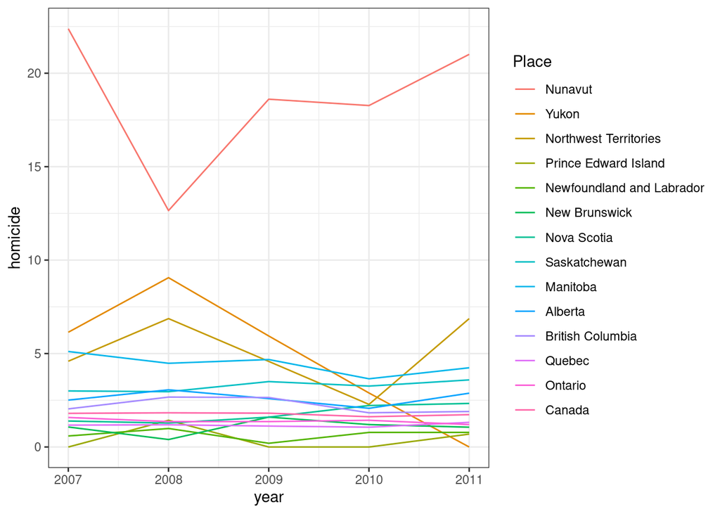

```r
## save the results
saveRDS(sdat3,file="./data/CA_homicide.rds")

##Note: For analysis in R, it is generally best to keep your data in long format and pivot_wider() it as necessary (e.g. when creating a human-readable table for output).

#####################################################################################
##PART 2: Pictures
#####################################################################################
## load data
mdat <- readRDS("./data/CA_homicide.rds")

##One of the advantages of long format is that it allows us to use some of R’s more powerful graphics tools such as the ggplot2 and lattice packages (and it’s what most statistics packages expect):
library(ggplot2)
theme_set(theme_bw())  ## black-and-white theme
## set up basic plot:
p1 <- ggplot(mdat,aes(year,homicide,colour=Place))
## ggplot produces an R object which can then be printed (=displayed in a graphics window), or saved (or exported to a graphics file via ggsave()):
print(p1+geom_line())
```

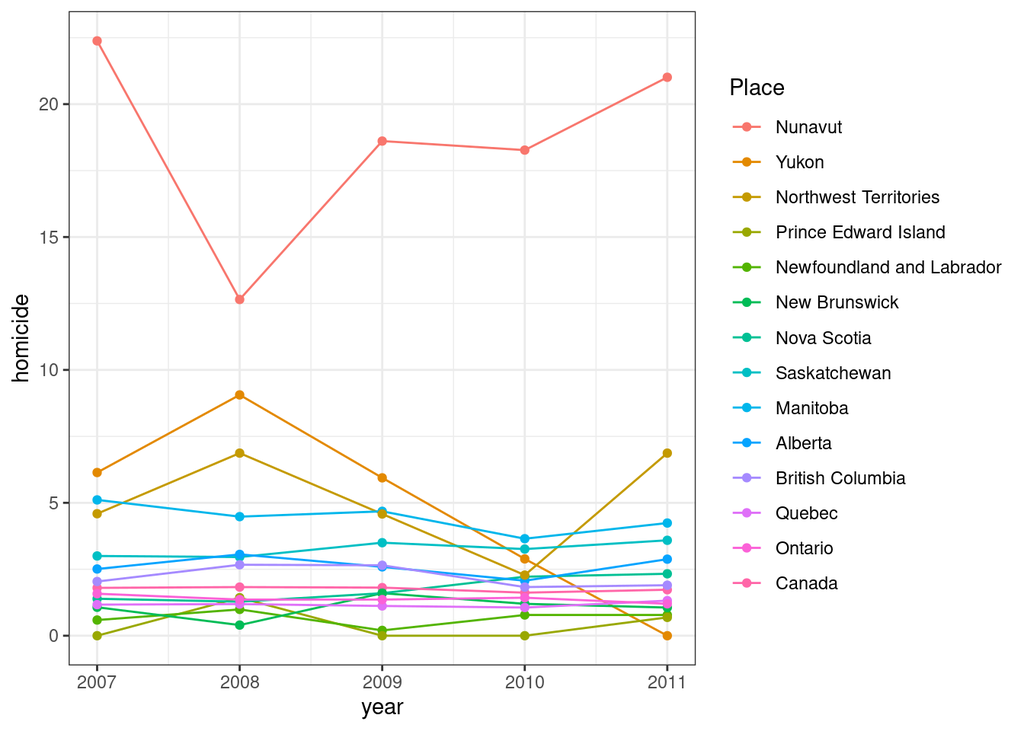

```r
print(p1+geom_line() +geom_point())
```

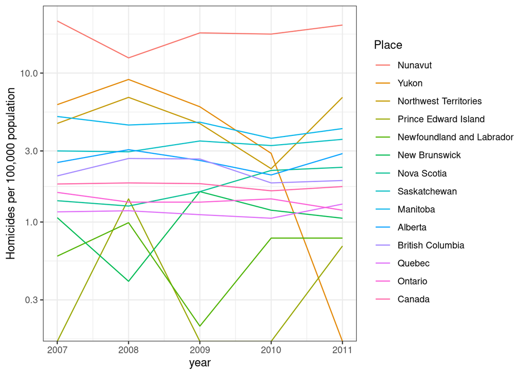

```r
## Might be better on a log scale, with a sensible y-axis label:
p1L <- (p1
    + geom_line()
    + scale_y_log10()
    + labs(y="Homicides per 100,000 population")
)
print(p1L)
```

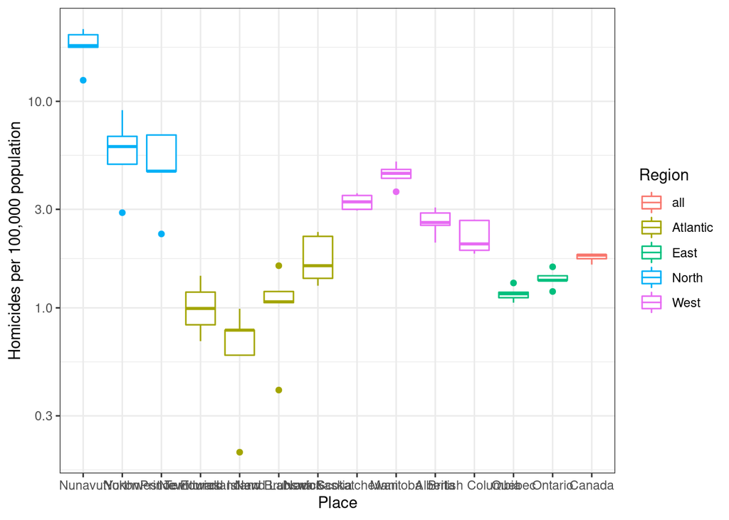

```r
##Maybe we don’t care about time at all:
b1 <- (ggplot(mdat,aes(x=Place,y=homicide,
                       colour=Region))
    + geom_boxplot(outlier.colour=NULL)  ## set outlier points to same colour as boxes
    + scale_y_log10()
    + labs(y="Homicides per 100,000 population")
)
print(b1)
```

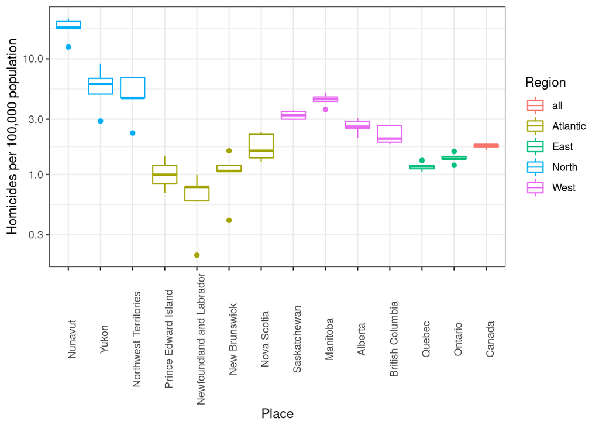

```r
## The x-axis tick labels overlap enough to be unreadable (unless we resize the plot to be ridiculously long and narrow).
## We could rotate them 90 degrees to be vertical:
b1_vertlabels <- b1+theme(axis.text.x=element_text(angle=90))
print(b1_vertlabels)
```

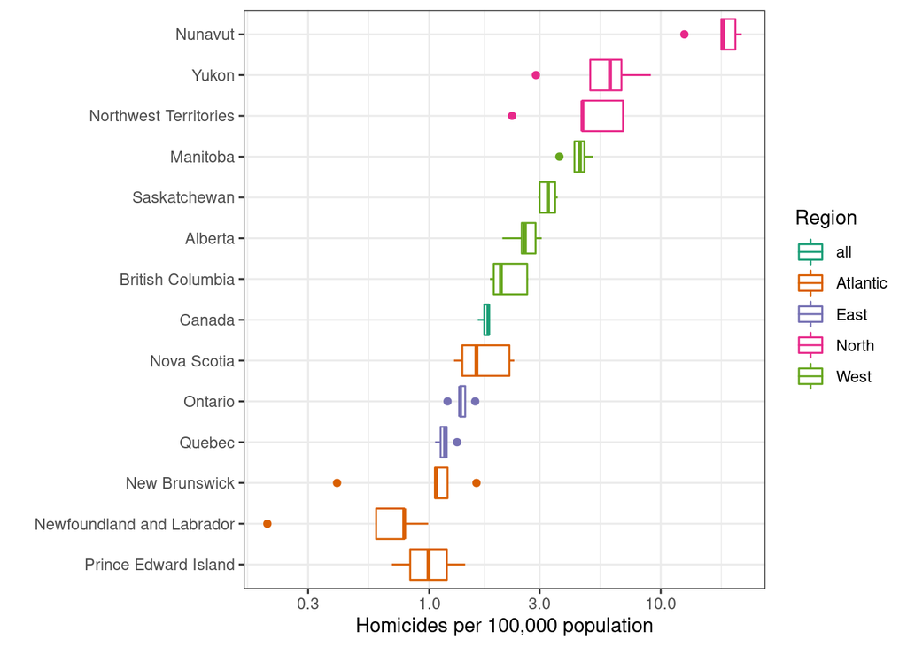

```r
## Note: In general if you want to tweak a ggplot plot, Google it or search the ggplot theme documentation or the ggplot cheat sheet for more information …

## Rotating the whole plot is less familiar, but arguably better. Here I’m also (1) changing the colour palette and (2) changing the order of the Place variable, using %+% to substitute a different set of data into an existing plot:
mdat_sort <- mdat %>% mutate(across(Place,~forcats::fct_reorder(.,homicide)))
print(b1
      %+% mdat_sort  ## substitute sorted data
      + coord_flip()      ## rotate entire plot
      + xlab("")          ## x-label redundant
      + scale_colour_brewer(palette="Dark2") ## change palette
      )
```

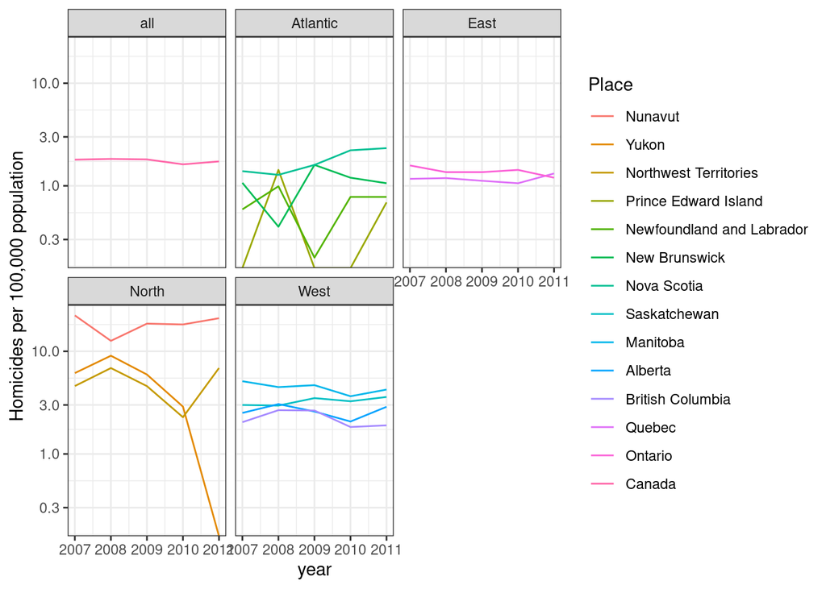

```r
## Maybe we want to make our line graph less busy:
print(p1L+facet_wrap(~Region))
```

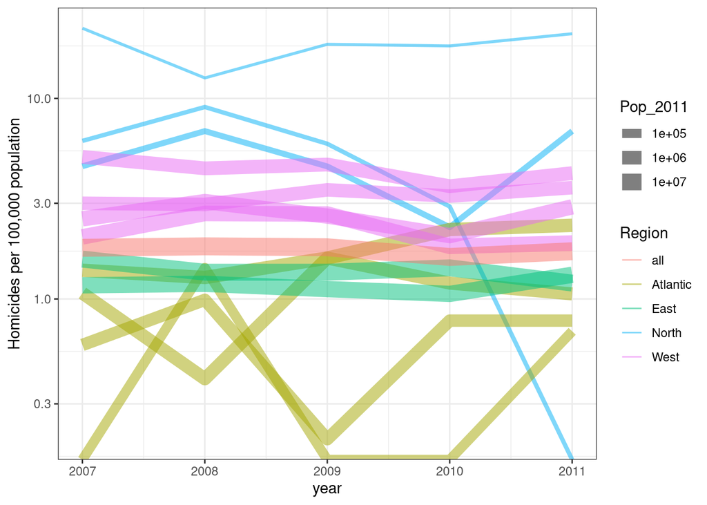

```r
## We could also code population size by line width:
p2 <- (ggplot(mdat,
             aes(x=year,y=homicide,colour=Region,size=Pop_2011,
                 group=Place))
    + geom_line(alpha=0.5)
    + scale_y_log10()
    + scale_size_continuous(trans="log10")
    + labs(y="Homicides per 100,000 population")
)
print(p2)
```

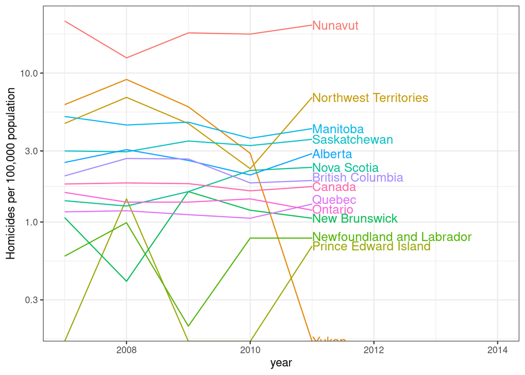

```r
## Using the directlabels package:
library(directlabels)
print(p1L
    + expand_limits(x=2014)  ## add a little more space
    + geom_dl(aes(label=Place),method="last.bumpup")
    + theme(legend.position="none")  ## don't need the legend any more
)
```

## Class 6

Date: Feb 4, 2021

```r
QMEEpath <- "~/classes/QMEE/docs/data/"
list.files(path=QMEEpath, pattern="*.csv") # create list of all .csv files in folder
```

```
##  [1] "ants.csv"               "CA_homicide.csv"        "CA_popdat.csv"
##  [4] "dll.csv"                "lizards.csv"            "parademo.csv"
##  [7] "portal_data_joined.csv" "religion_basic.ccsv"    "skewdat.csv"
## [10] "village.csv"
```

```r
## file <- "CA_homicide.csv"
## temp_dat <- read_csv(file = paste(QMEEpath,file, sep=''),col_types=cols())

## dealing with emty rows and cols
library(tidyverse)
library(janitor) # it says that
## minimal reproduciable example
dd <- tibble(x=c(LETTERS[1:5],rep("",3)),
             y=c(1:5,rep(NA,3)),
             z=rep(NA,8)
             )

dd[-(6:7),-3]
```

```
## # A tibble: 6 x 2
##   x         y
##   <chr> <int>
## 1 "A"       1
## 2 "B"       2
## 3 "C"       3
## 4 "D"       4
## 5 "E"       5
## 6 ""       NA
```

```r
## janitor lib
remove_empty(dd,c("rows","cols"))
```

```
## # A tibble: 8 x 2
##   x         y
##   <chr> <int>
## 1 "A"       1
## 2 "B"       2
## 3 "C"       3
## 4 "D"       4
## 5 "E"       5
## 6 ""       NA
## 7 ""       NA
## 8 ""       NA
```

```r
##BMB to be
emptyrows2 <- function(x){

}

## or change the empty cells with NAs
dd %>% mutate_if(is.character,
                 ~replace(., which(!nzchar(.)),NA))
```

```
## # A tibble: 8 x 3
##   x         y z
##   <chr> <int> <lgl>
## 1 A         1 NA
## 2 B         2 NA
## 3 C         3 NA
## 4 D         4 NA
## 5 E         5 NA
## 6 <NA>     NA NA
## 7 <NA>     NA NA
## 8 <NA>     NA NA
```

```r
## ~ mean on fly, . means columns

?mutate_if

## the importance of clean data coding standards
tmp_table <- read.csv(text="
common_name_date
sunfish_2021
xx_2020
")
library(dplyr)
## letr's separate the column based on "_"
(tmp_table %>% separate(common_name_date,c("A","B"),sep="([_])")
          %>% head() #
)
```

```
##         A    B
## 1 sunfish 2021
## 2      xx 2020
```

```r
library(skimr)

library(MASS)
```

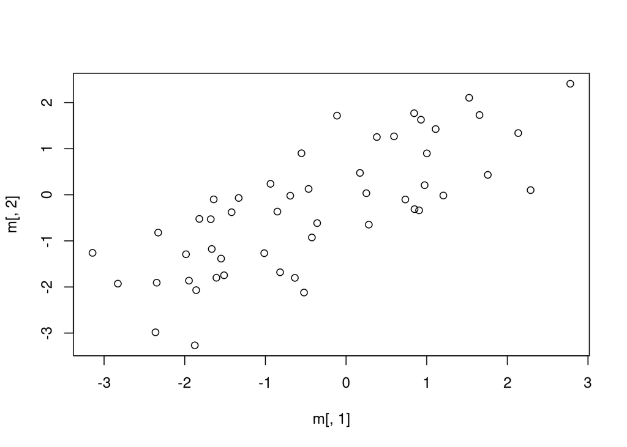

```r
m <- mvrnorm(50, mu=c(0,0),Sigma = matrix(c(2,1.5,1.5,2),2)) # corelated data set
plot(m[,1],m[,2])
```

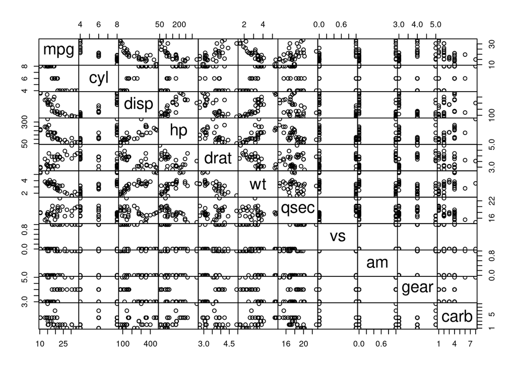

```r
m <- rbind(m,c(-2,2))
pairs(mtcars,gap=0) ## take the gaps out
```

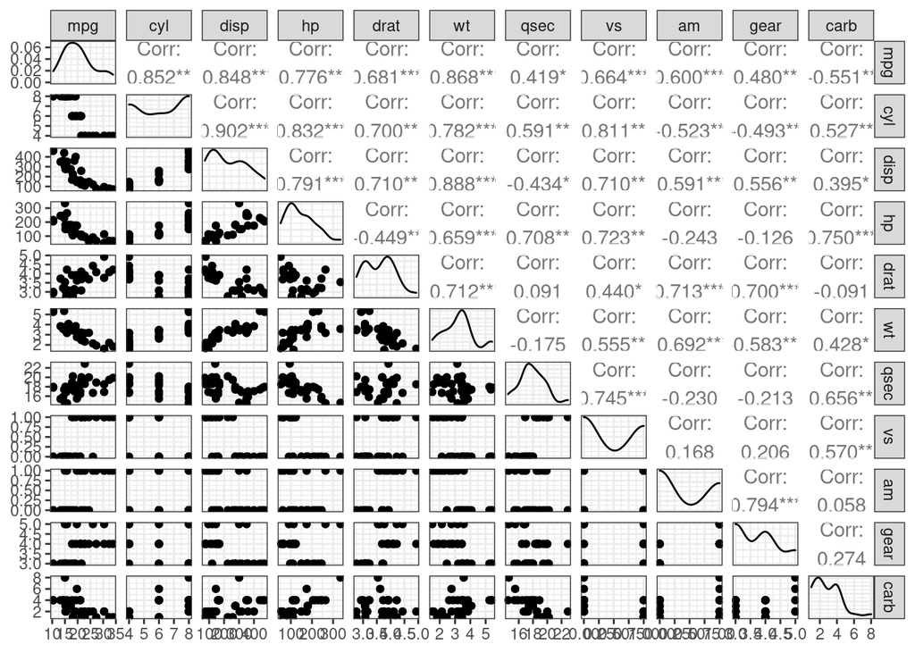

```r
## fancier than pairs
library(GGally)
ggpairs(mtcars)
```

```r
library(car)
```

## Class 7

Date: Feb 9, 2021

- stats philosophy

[output not shown]